# Splines: What and Why

Zheyuan Li

2022-10-19

```r
library(ggplot2)
```

# 1 Why Do We Use Splines?

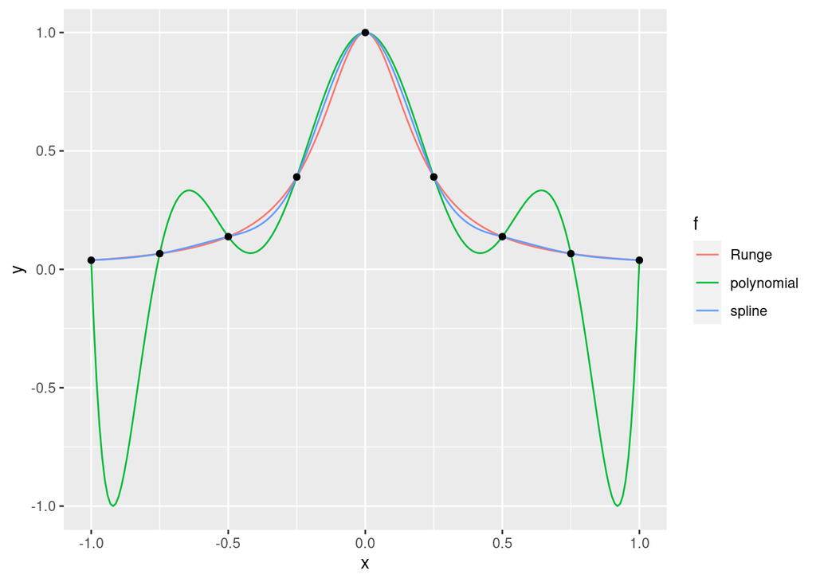

```r
n <- 8
## interpolation nodes (from Runge function)
x.node <- seq.int(-1, 1, length.out = n + 1)
y.node <- 1 / (1 + 25 * x.node ^ 2)
## evaluation point (from Runge function)
x.runge <- seq.int(-1, 1, 0.01)
y.runge <- 1 / (1 + 25 * x.runge ^ 2)
## polynomial interpolant
y.poly <- c(outer(x.runge, 0:n, "^") %*% solve(outer(x.node, 0:n, "^"), y.node))
## natural cubic spline interpolant
y.spl <- spline(x.node, y.node, method = "natural", xout = x.runge)$y
## plot
fctr <- factor(c("Runge", "polynomial", "spline"), c("Runge", "polynomial", "spline"))
xy <- data.frame(x = rep.int(x.runge, 3),
                 y = c(y.runge, y.poly, y.spl),
                 f = rep(fctr, each = length(x.runge)))
ggplot(data = xy, mapping = aes(x, y)) +
  geom_line(mapping = aes(color = f)) +
  geom_point(data = data.frame(x = x.node, y = y.node), mapping = aes(x, y))
```

# 2 What is a Splines?

A splines is a piecewise polynomial, smoothly connected at some break points called interior knots.

The widely used cubic spline (where “cubic” refers to its degree), is a piecewise cubic polynomial with continuous 2nd derivatives at its break points.

Here is a cubic spline on $[1, 6]$ with interior knots at $x = 2, 3, 4, 5$:

$$\begin{equation*}
f(x) = \begin{cases}
1.0900 + 0.610(x - 1) - 0.060(x - 1) ^ 2 - 0.3067(x - 1) ^ 3 & x \in
[1, 2),\\
1.3333 - 0.430(x - 2) - 0.980(x - 2) ^ 2 + 0.7867(x - 2) ^ 3 & x \in
[2, 3),\\
0.7100 - 0.030(x - 3) + 1.380(x - 3) ^ 2 - 0.7133(x - 3) ^ 3 & x \in
[3, 4),\\
1.3467 + 0.590(x - 4) - 0.760(x - 4) ^ 2 + 0.2917(x - 4) ^ 3 & x \in
[4, 5),\\
1.4683 - 0.055(x - 5) + 0.115(x - 5) ^ 2 + 0.1233(x - 5) ^ 3 & x \in
[5, 6].
\end{cases}
\end{equation*}$$

It is straightforward to calculate its derivatives:

$$\begin{equation*}
f'(x) = \begin{cases}
\phantom{-}0.610 - 0.12(x - 1) - 0.920(x - 1) ^ 2 & x \in [1, 2),\\
-0.430 - 1.96(x - 2) + 2.360(x - 2) ^ 2 & x \in [2, 3),\\
-0.030 + 2.76(x - 3) - 2.140(x - 3) ^ 2 & x \in [3, 4),\\
\phantom{-}0.590 - 1.52(x - 4) + 0.875(x - 4) ^ 2 & x \in [4, 5),\\
-0.055 + 0.23(x - 5) + 0.370(x - 5) ^ 2 & x \in [5, 6].
\end{cases}
\end{equation*}$$

$$\begin{equation*}
f''(x) = \begin{cases}
-0.12 - 1.84(x - 1) & x \in [1, 2),\\
-1.96 + 4.72(x - 2) & x \in [2, 3),\\
\phantom{-}2.76 - 4.28(x - 3) & x \in [3, 4),\\
-1.52 + 1.75(x - 4) & x \in [4, 5),\\
\phantom{-}0.23 + 0.74(x - 5) & x \in [5, 6].
\end{cases}
\end{equation*}$$

$$\begin{equation*}
f'''(x) = \begin{cases}
-1.84 & x \in [1, 2),\\
\phantom{-}4.72 & x \in [2, 3),\\
-4.28 & x \in [3, 4),\\
\phantom{-}1.75 & x \in [4, 5),\\
\phantom{-}0.74 & x \in [5, 6].
\end{cases}
\end{equation*}$$

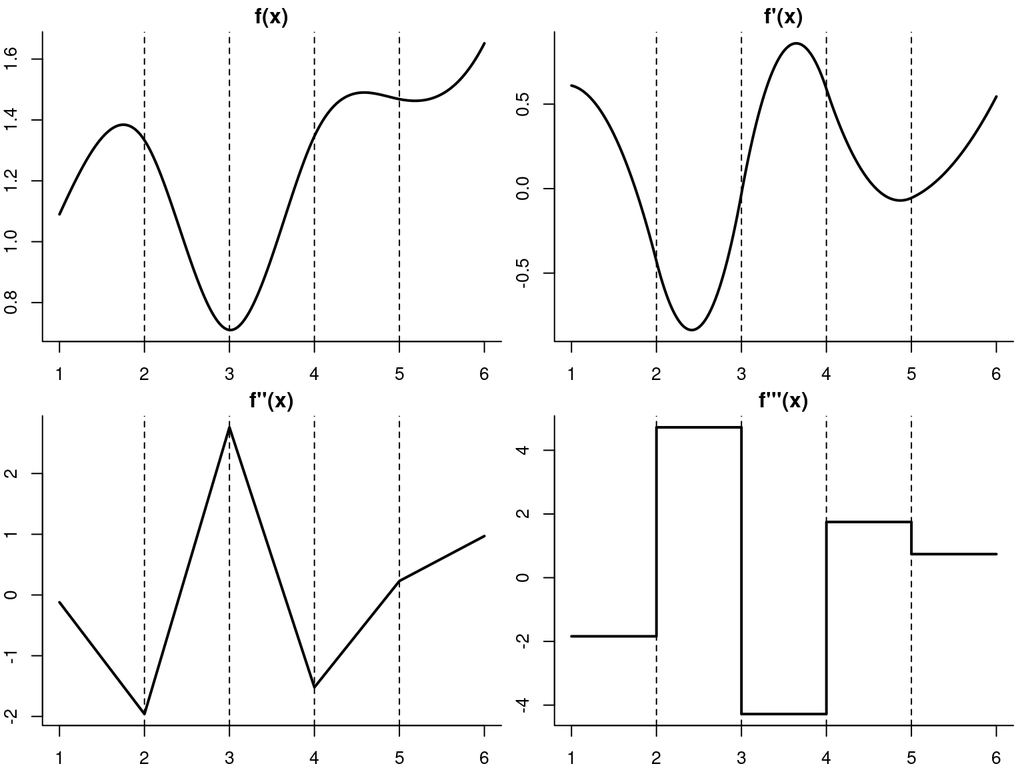

# 3 What are B-Splines?

B-Splines are Basis Splines. They provide an alternative way for expressing splines. It is more convenient than piecewise polynomials, and they are mathematically equivalent.

Basis representation for the above example cubic spline:

$$\begin{equation*}
f(x) = 0.44B_1(x) + 1.11B_2(x) + 1.66B_3(x) + 0.25B_4(x) + 1.60B_5(x) +
1.43B_6(x) + 1.49B_7(x) + 2.52B_8(x).
\end{equation*}$$

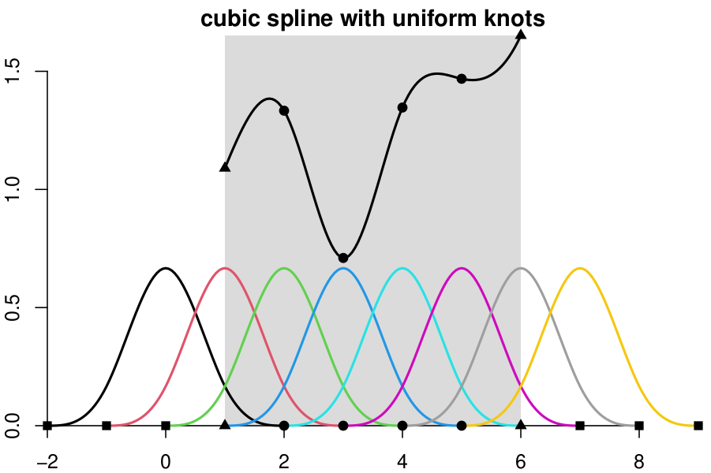

**Important:** the number of cubic B-splines = the number of interior knots + 4